# Analiza wpływu wysokości akcyzy na wyroby tytoniowe na wydatki medyczne i PKB

2025-11-16

## Cel i zakres badania

## Polityka fiskalna a zdrowie w Europie

**Badanie:** Celem projektu jest analiza zależności między wielkością populacji, PKB, średnimi płacami, wydatkami publicznymi i wpływami z akcyzy z wyrobów tytoniowych  
**Zakres:** 26 krajów (2019)  
**Metody:** Analiza korelacji i regresji

## Wykorzystane Pakiety

library(readxl)

library(dplyr)

library(ggplot2)

library(GGally)

library(rnaturalearth)

library(rnaturalearthdata)

## Pakiet library(readxl)

Autorzy:Hadley Wickham, Jennifer Bryan

Wybrane funkcje:

read_excel( path, – ścieżka do pliku Excel  
sheet = NULL, nazwa lub numer arkusza, który chcemy wczytać.  
range = NULL,- – zakres komórek (np. “A1:D20”)  
col_names = TRUE, czy pierwsza linia ma być traktowana jako nazwy kolumn  
col_types = NULL, - typy kolumn (“text”, “numeric”, “date”, “logical”)  
na = ““, znak oznaczający brak danych  
trim_ws = TRUE, usuwa zbędne spacje w komórkach.  
skip = 0, liczba wierszy do pominięcia na początku arkusza  
n_max = Inf, maksymalna liczba wierszy do wczytania.  
)

## Pakiet library(dplyr)

Autorzy: Hadley Wickham, Romain François, Lionel Henry, Kirill Müller

Wybrane funkcje:

r filter(.data, …) # filtruje wiersze według warunku  
select(.data, …) # wybiera kolumny  
mutate(.data, …) # tworzy nowe kolumny  
arrange(.data, …) # sortuje wiersze summarise(.data, …) # agreguje dane  
group_by(.data, …) # grupuje dane  
ungroup(.data) # usuwa grupowanie  
rename(.data, …) # zmienia nazwy kolumn  
distinct(.data, …) # usuwa duplikaty wierszy

## Pakiet library(ggplot2)

ggplot(data) # inicjuje wykres  
aes(x, y, …) # definiuje estetyki (mapowania)  
geom_point() # warstwa punktów  
geom_line() # warstwa linii  
geom_bar() # warstwa słupków  
geom_histogram() # warstwa histogramu  
facet_wrap(~variable) # panele według zmiennej  
labs(title, x, y) # etykiety osi i tytuł  
theme_bw() # motyw wykresu  
scale_x_continuous() # skala osi X  
scale_y_log10() # logarytmiczna skala Y

## Pakiet library(GGally)

Autorzy: Barret Schloerke, Hadley Wickham

Wybrane funkcje:

r ggpairs(data) # macierz wykresów rozrzutu  
ggcorr(data) # macierz korelacji  
ggnostic(model) # diagnostyka modelu  
ggcoef(model) # wykres współczynników modelu  
ggnetwork(network) # wizualizacja sieci  
ggsurv(survfit) # krzywe przeżycia  
ggtable(data) # tabela jako wykres  
theme_grey() # domyślny motyw  
wrap(plot, ncol) # opakowuje wiele wykresów

## Pakiet library(rnaturalearth)

Autorzy: Andy South

Wybrane funkcje:

ne_countries(scale) # dane krajów (scale: 10, 50, 110)  
ne_states() # dane stanów/prowincji  
ne_coastline() # linie brzegowe  
ne_download(scale, type) # pobiera dane z Natural Earth  
ne_file_name(scale, type) # generuje nazwę pliku  
ne_load() # ładuje dane z pliku  
ne_bbox() # ramka ograniczająca  
ne_find() # znajduje obiekty przestrzenne  
ne_clean() # czyści dane przestrzenne

## Pakiet library(rnaturalearthdata)

Autorzy: Andy South

Wybrane funkcje:

countries110 # kraje w skali 1:110 milionów  
countries50 # kraje w skali 1:50 milionów  
countries10 # kraje w skali 1:10 milionów  
states50 # stany w skali 1:50 milionów  
coastline110 # linie brzegowe 1:110 milionów  
lakes110 # jeziora w skali 1:110 milionów  
rivers110 # rzeki w skali 1:110 milionów

## Źródła danych

Źródła danych:

-Eurostat (w postaci plików xlsx)

```r
dane1 <- read_excel("Tobacco_consumption_HLTH2022-2.xlsx", sheet = "T1")
OdsetekPalacy <- dane1[, 1:2] %>%
  arrange(.[[1]]) %>%
  rename(Country = 1, Smokers = 2)
```

-Taxfoundation (pobierane bezpośrednio ze strony)

```r
library(rvest)
library(dplyr)
url <- "https://taxfoundation.org/data/all/eu/cigarette-tax-europe-2019/"
page <- read_html(url)
dane6 <- page %>% html_table(fill = TRUE)
```

## Informacje teoretyczne o danych

- **Odsetek palących**: Eurostat - dane dotyczące konsumpcji tytoniu w populacji dorosłych
- **Dane demograficzne**: Eurostat - liczebność populacji krajów europejskich
- **Wskaźniki ekonomiczne**: Eurostat - PKB per capita w USD
- **Akcyza tytoniowa**: Tax Foundation - wysokość podatku akcyzowego na paczkę papierosów
- **Wydatki medyczne**: Eurostat - całkowite wydatki na ochronę zdrowia w mln

## Zebrane dane

Dane zostały uszeregowane i zebrane do jednej tabeli dane_final Zawieraja następujące elementy

-Odsetek populacji danego kraju palący papierosy w %

-Liczebność populacji danego kraju

-PKB danego kraju

-Wysokość akcyzy nakładanej na paczke papierosów

-Wydatki roczne w mln na opiekę medyczną

## Przykładowe dane

Przykładowe dane

| Country | Smokers | Population | GDP_per_capita | Akcyza | Wydatki_na_medycyne |
| --- | --- | --- | --- | --- | --- |
| Austria | 20.2 | 8858775 | 41970 | 2.95 | 42045.05 |
| Belgium | 14.6 | 11467923 | 33370 | 3.77 | 52059.64 |
| Bulgaria | 28.7 | 7000039 | 38760 | 1.76 | 4364.00 |
| Croatia | 21.8 | 4076246 | 34880 | 2.04 | 3785.01 |
| Cyprus | 21.2 | 875900 | 29000 | 2.57 | 1637.70 |
| Denmark | 11.7 | 5806081 | 18570 | 3.23 | 31424.46 |

## Metoda analizy

W analizie wykorzystano następujące metody statystyczne:

1. **Analiza korelacji Pearsona** - badanie liniowych zależności między zmiennymi
2. **Wizualizacja przestrzenna** - mapy cieplne pokazujące rozkład geograficzny zmiennych
3. **Analiza wielowymiarowa** - macierz korelacji i wykresy rozrzutu
4. **Regresja liniowa wieloraka** - modelowanie wpływu wielu zmiennych na odsetek palących

Analiza pozwala na identyfikację zależności między polityką fiskalną (akcyza) a wskaźnikami zdrowotnymi i ekonomicznymi.

## Średnie wydatki

Podstawowe statystyki opisowe

| Liczba krajów | Średni odsetek palących (%) | Średnie PKB per capita (USD) | Średnia akcyza (EUR) | Średnie wydatki medyczne |
| --- | --- | --- | --- | --- |
| 26 | 17.6 | 31954 | 3 | 52961 |

## Odsetek palacych

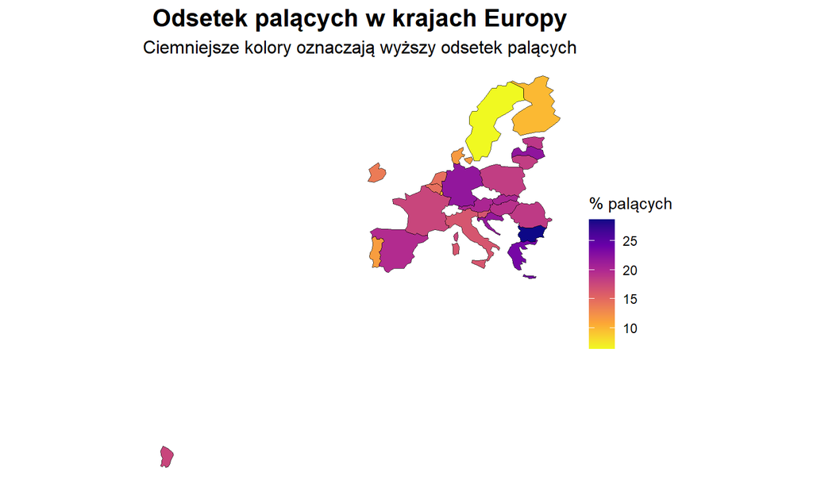

## Korelacja

Rozszerzona macierz korelacji między zmiennymi

| Zmienna.X | Zmienna.Y | Współczynnik.korelacji | Siła.korelacji |
| --- | --- | --- | --- |
| Akcyza | PKB per capita | -0.065 | Słaba |
| Akcyza | Odsetek palących | -0.405 | Umiarkowana |
| Akcyza | Wydatki medyczne per capita | 0.627 | Silna |
| PKB per capita | Odsetek palących | 0.182 | Słaba |
| PKB per capita | Wydatki medyczne per capita | -0.024 | Słaba |
| PKB per capita | Odsetek palących | 0.182 | Słaba |
| Wydatki medyczne per capita | Odsetek palących | -0.637 | Silna |
| Liczba ludności | Odsetek palących | 0.122 | Słaba |
| Liczba ludności | Akcyza | 0.155 | Słaba |
| Wydatki medyczne całkowite | Odsetek palących | 0.060 | Słaba |

## Wizualizacja zależności wielowymiarowych

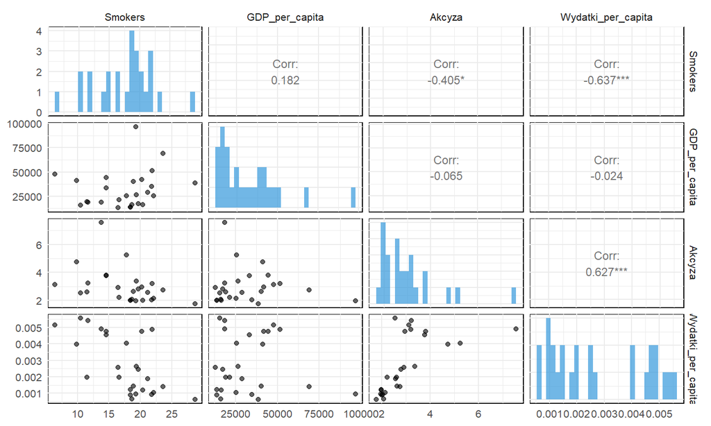

## Analiza regresji

Wyniki regresji liniowej - Czynniki wpływające na odsetek palących

|  | Parametr | Szacunek | Błąd.standardowy | p.value | Istotność |
| --- | --- | --- | --- | --- | --- |
| (Intercept) | (Intercept) | 21.084 | 2.463 | 0.0000 | *** |
| GDP_per_capita | PKB per capita | 0.000 | 0.000 | 0.3102 |  |
| Akcyza | Akcyza | 0.019 | 0.798 | 0.9815 |  |
| Wydatki_per_capita | Wydatki medyczne per capita | -1782.691 | 576.836 | 0.0053 | *** |

## Wnioski z analizy

### Polityka akcyzowa

Wysokość akcyzy **nie koreluje silnie** z zamożnością kraju (r = -0.07), co sugeruje, że decyzje podatkowe są niezależne od poziomu rozwoju gospodarczego.

### Wydatki medyczne

Wydatki medyczne per capita korelują z odsetkiem palących. (r = -0.64).

## Ograniczenia analizy

- Dane pochodzą z różnych źródeł (Eurostat, Tax Foundation), co może powodować różnice w metodologii pomiaru.
- Analiza opiera się na jednym roku (2019), przez co nie uwzględnia trendów czasowych ani efektów opóźnień.
- Nie uwzględniono czynników społecznych i kulturowych (np. edukacji, kampanii antynikotynowych), które również wpływają na odsetek palących.
- Wydatki medyczne i akcyza są wartościami zagregowanymi na poziomie kraju - nie analizujemy struktury wydatków.
- Model regresji wielorakiej wyjaśnia tylko część zmienności (≈ 43.4%), co oznacza istnienie innych silnych determinant palenia.

## Kompleksowe podejście

Skuteczna polityka antytytoniowa powinna **łączyć instrumenty fiskalne** (akcyza) z **działaniami edukacyjnymi** i **programami wsparcia** dla osób chcących rzucić palenie.

## Zróżnicowanie regionalne

Wysoka zmienność między krajami wskazuje na potrzebę **dostosowania polityki** do specyfiki regionalnej i kulturowej poszczególnych społeczeństw.

## Podsumowanie i zakończenie

Dziękujemy za uwagę!  
Analiza zapisów akcyzowych, zachowań zdrowotnych i wskaźników ekonomicznych  
pokazuje, że polityka fiskalna może odgrywać kluczową rolę w kształtowaniu zdrowia publicznego.

Filip Kasprzycki • Mateusz Kaczkowski